# R in an Hour

June 28, 2015

## What are we going to cover

- Highlights of R language, a bit of history and its characteristics
- Great uses to consider R language and eco-system
- Demo/Walkthrough of Real R projects
- We WILL NOT cover deep language syntax - sorry engineers, separate Talk ;)

[figure not shown]

## R Highlights and Characteristics…

## R - What is it? Where did it come from?

- Historically a DSL for Statistic analysis and reporting
- Based from S language
  - S in 1970s
  - R dialect of S in late 1990's
- Implemented in C and FORTAN
- Heavy adoption in Data Science in recent years
- Heavy community support to extend R core with packages - CRAN
- Competition from Python

## R - Language Characteristics

- Dynamic Typing
- Interpreted
- Functional, with some OO littered in
- Declarative vs Imperative – emphasis on set operations, versus scalar
- Potentially large learning curve for developers with OO or Imperative Language Backgrounds

## R - Foundational Basics

- Vectors

```r
someVector <- c(1,2,3)
```

- Matrix

```r
someMatrix <- c(1,2,3,4,5,6, nrow=2,ncol=3)
```

- List

```r
someList <- list(someMatrix,someVector)
```

## R - Data Frame (Table)

- In R we can create tables (similar to tables in RDBMS)
- Create a Data Frame (Table)

```r
library(data.table)

set.seed(100)

dt <- data.table(id = c(1:100),
                 value = c(sample(1:1000,100)))
```

## R - Accessing element from data table

- To access an element, we can use "subsetting"
- By Row:

```r
dt[2]
```

```
##    id value
## 1:  2   258
```

- Columns by name:

```r
dt$value[2]
```

```
## [1] 258
```

## R - Filtering data tables

- Let's filter table rows with ID of two via "subsetting"
- Subsetting is R core feature to select

```r
dt[dt$id == 2]
```

```
##    id value
## 1:  2   258
```

- Or, we can use the dplyr (or plyr) filter method…

```r
library(dplyr)
filter(dt,id == 2)
```

```
##    id value
## 1:  2   258
```

## R - Chaining

- Chain several aggregrate operations

```r
filter(dt, id > 10) %>%
        summarize(count = n(),
                  mean = mean(value),
                  median = quantile(value,0.50),
                  ninetyPercent = quantile(value,0.90),
                  total = sum(value))
```

```
##    count     mean median ninetyPercent total
## 1:    90 513.8444  526.5         897.3 46246
```

## R - Plotting

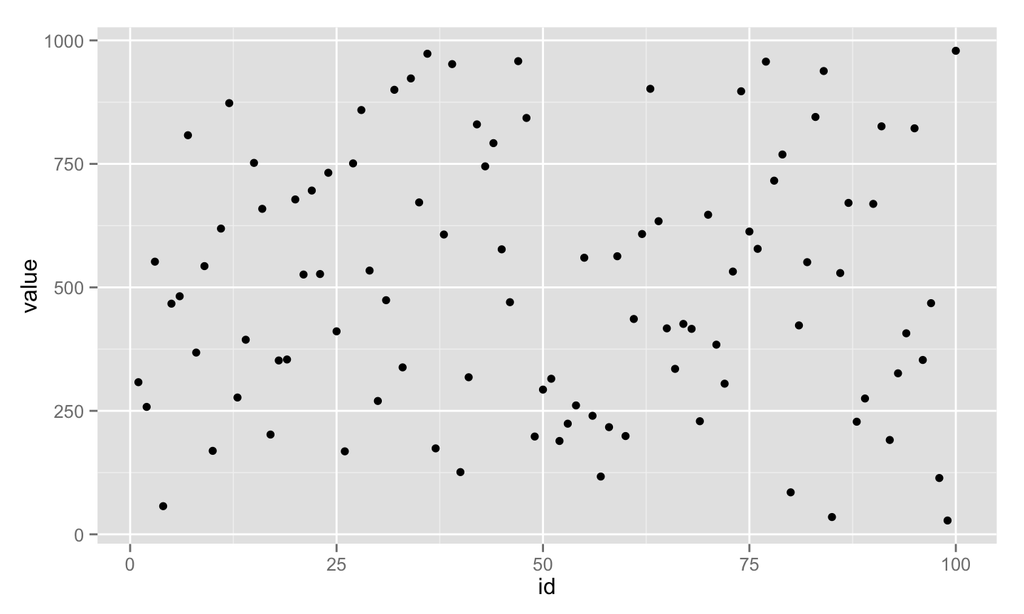

```r
library(ggplot2)
p <- qplot(x=id, y=value, data=dt)
print(p)
```

## R - Key Language Takeaway

### Avoid Looping Constructs!

- R Language Performance - traditional procedural looping constructs not as efficient as set based constructs
- Much effort by community to build performant set based packages, such as `dplyr` and `data.table`

## R Uses and Ecosystem…

## What is it good for?

- Statistics/Numerical analysis and Reporting
- Exploratory Analysis
- Lightweight Reporting
- Lightweight Presentations (like this one)

## What is is NOT good for?

- Systems Programming
- Complex Reporting

## Ecosystem

- Open source Development Community - R Core, CRAN
- Commercial Contributors - RStudio, Revolution Analytics
- Affliation with Open Source Agile tools - GitHub, RPubs, Markdown

## RStudio

- IDE
- Interactive Reporting Server

## Markdown

### Simplistic plain text Markup language

- No tags (like in JSON, HTML, XML)
- Awesome for short documents, wikis – Github supports natively

```r
# Level 1 Heading

## Level 2 Heading

### Level 3 Heading

- Unordered List Item (bullet)

1. Order List Item (bullet)

[Some Link Title](http://somehypertextlink.com)
```

## Markdown

### Rendering

### Level 3 Heading

- Unordered List Item (bullet)
1. Order List Item (bullet)

[Some Link Title](http://somehypertextlink.com)

## RMarkdown & Literal Programming

- **Literal Programming**: Documenting logical flow in plain English, embedding code supporting the flow
- RStudio supports Literal Programming
- RMarkdown is implementation of Markdown, allowing:
  - Embed of dynamic R code
  - Output of different formats, such as HTML, PDF, etc
- This presentation was implemented with RMarkdown, using Google ioslide output format.
- RStudio supports interactive reporting via RMarkdown and Shiny framework

## RPubs

- Community Web Server for Publishing results
- Single click publish from RStudio for RMarkdown Content
- Free Edition is restrictive for full (public access)

## Walkthrough of Reproducible Research Project

## Walkthrough of HAR Extract Report

## Bye!

## References

- R Language: http://www.r-project.org/
- RStudio: http://www.rstudio.com/
- CRAN: http://cran.r-project.org/
- Markdown: http://daringfireball.net/projects/markdown/
- RMarkdown: http://rmarkdown.rstudio.com/
- ioslides: http://rmarkdown.rstudio.com/ioslides_presentation_format.html#presenter-mode
- RPubs: http://rpubs.com/
- Revolution Analytics: http://www.revolutionanalytics.com/